# Part I - Ford GoBike Dataset

## by Samuel Tsuma

- Introduction
- Preliminary Wrangling
- Assessing
- Cleaning
- Univariate Exploration
- Bivariate Exploration
- Multivariate Exploration
- Conclusion

## Introduction

> This data set includes information about individual rides made in a bike-sharing system covering the greater San Francisco Bay area.

## Preliminary Wrangling

```python
# import all packages and set plots to be embedded inline
import numpy as np
import pandas as pd
import matplotlib.pyplot as plt
import seaborn as sb

%matplotlib inline
```

> We load in the dataset, make a copy and then explore it.

```python
# loading in the dataset into a pandas dataframe, then making a copy
bike_df = pd.read_csv('201902-fordgobike-tripdata.csv')
bike_data = bike_df.copy()
```

```python
bike_data.info()
```

```
<class 'pandas.core.frame.DataFrame'>
RangeIndex: 183412 entries, 0 to 183411
Data columns (total 16 columns):
 #   Column                   Non-Null Count   Dtype
---  ------                   --------------   -----
 0   duration_sec             183412 non-null  int64
 1   start_time               183412 non-null  object
 2   end_time                 183412 non-null  object
 3   start_station_id         183215 non-null  float64
 4   start_station_name       183215 non-null  object
 5   start_station_latitude   183412 non-null  float64
 6   start_station_longitude  183412 non-null  float64
 7   end_station_id           183215 non-null  float64
 8   end_station_name         183215 non-null  object
 9   end_station_latitude     183412 non-null  float64
 10  end_station_longitude    183412 non-null  float64
 11  bike_id                  183412 non-null  int64
 12  user_type                183412 non-null  object
 13  member_birth_year        175147 non-null  float64
 14  member_gender            175147 non-null  object
 15  bike_share_for_all_trip  183412 non-null  object
dtypes: float64(7), int64(2), object(7)
memory usage: 22.4+ MB
```

```python
bike_data.head()
```

|  | duration_sec | start_time | end_time | start_station_id | start_station_name | start_station_latitude | start_station_longitude | end_station_id | end_station_name | end_station_latitude | end_station_longitude | bike_id | user_type | member_birth_year | member_gender | bike_share_for_all_trip |
| --- | --- | --- | --- | --- | --- | --- | --- | --- | --- | --- | --- | --- | --- | --- | --- | --- |
| 0 | 52185 | 2019-02-28 17:32:10.1450 | 2019-03-01 08:01:55.9750 | 21.0 | Montgomery St BART Station (Market St at 2nd St) | 37.789625 | -122.400811 | 13.0 | Commercial St at Montgomery St | 37.794231 | -122.402923 | 4902 | Customer | 1984.0 | Male | No |
| 1 | 42521 | 2019-02-28 18:53:21.7890 | 2019-03-01 06:42:03.0560 | 23.0 | The Embarcadero at Steuart St | 37.791464 | -122.391034 | 81.0 | Berry St at 4th St | 37.775880 | -122.393170 | 2535 | Customer | NaN | NaN | No |
| 2 | 61854 | 2019-02-28 12:13:13.2180 | 2019-03-01 05:24:08.1460 | 86.0 | Market St at Dolores St | 37.769305 | -122.426826 | 3.0 | Powell St BART Station (Market St at 4th St) | 37.786375 | -122.404904 | 5905 | Customer | 1972.0 | Male | No |
| 3 | 36490 | 2019-02-28 17:54:26.0100 | 2019-03-01 04:02:36.8420 | 375.0 | Grove St at Masonic Ave | 37.774836 | -122.446546 | 70.0 | Central Ave at Fell St | 37.773311 | -122.444293 | 6638 | Subscriber | 1989.0 | Other | No |
| 4 | 1585 | 2019-02-28 23:54:18.5490 | 2019-03-01 00:20:44.0740 | 7.0 | Frank H Ogawa Plaza | 37.804562 | -122.271738 | 222.0 | 10th Ave at E 15th St | 37.792714 | -122.248780 | 4898 | Subscriber | 1974.0 | Male | Yes |

```python
bike_data.describe()
```

|  | duration_sec | start_station_id | start_station_latitude | start_station_longitude | end_station_id | end_station_latitude | end_station_longitude | bike_id | member_birth_year |
| --- | --- | --- | --- | --- | --- | --- | --- | --- | --- |
| count | 183412.000000 | 183215.000000 | 183412.000000 | 183412.000000 | 183215.000000 | 183412.000000 | 183412.000000 | 183412.000000 | 175147.000000 |
| mean | 726.078435 | 138.590427 | 37.771223 | -122.352664 | 136.249123 | 37.771427 | -122.352250 | 4472.906375 | 1984.806437 |
| std | 1794.389780 | 111.778864 | 0.099581 | 0.117097 | 111.515131 | 0.099490 | 0.116673 | 1664.383394 | 10.116689 |
| min | 61.000000 | 3.000000 | 37.317298 | -122.453704 | 3.000000 | 37.317298 | -122.453704 | 11.000000 | 1878.000000 |
| 25% | 325.000000 | 47.000000 | 37.770083 | -122.412408 | 44.000000 | 37.770407 | -122.411726 | 3777.000000 | 1980.000000 |
| 50% | 514.000000 | 104.000000 | 37.780760 | -122.398285 | 100.000000 | 37.781010 | -122.398279 | 4958.000000 | 1987.000000 |
| 75% | 796.000000 | 239.000000 | 37.797280 | -122.286533 | 235.000000 | 37.797320 | -122.288045 | 5502.000000 | 1992.000000 |
| max | 85444.000000 | 398.000000 | 37.880222 | -121.874119 | 398.000000 | 37.880222 | -121.874119 | 6645.000000 | 2001.000000 |

```python
# checking for null columns
bike_data.isnull().sum()
```

```
duration_sec                  0
start_time                    0
end_time                      0
start_station_id            197
start_station_name          197
start_station_latitude        0
start_station_longitude       0
end_station_id              197
end_station_name            197
end_station_latitude          0
end_station_longitude         0
bike_id                       0
user_type                     0
member_birth_year          8265
member_gender              8265
bike_share_for_all_trip       0
dtype: int64
```

## Assessing

### What is the structure of your dataset?

Norminal variables include:

- member_gender (male, female, other)
- user_type (customer, subscriber)
- bike_share_for_all_trip (yes, no)

The most notable issues at first glance are:

### Quality Issues

**#1**: Missing values in 6 columns: start_station_id, end_station_id, start_station_name, end_station_name, member_birth_year and member_gender.

**#2**: Wrong data types in these columns: start_time, end_time, start_station_id, end_station_id, bike_id, member_birth_year.

**#3**: Invalid entries in member_birth_year column, i.e the oldest registered member born in 1878.

> **Note**: There is no noticeable data **tidiness** issue in this dataset.

Let's clean the identified issues.

## Cleaning

### Issue 1: Missing values in 6 columns

### Define

> **Note**: Since there is no way of acquiring the missing values, and that the number of rows is significantly low, let's leave the columns as they are.

However,

> **IMPORTANT :** We will drop all rows without a `start_station_id` **and** `end_station_id`. This way, we are left only with data of members who *were recorded to have started and ended* at given stations.

### Code

```python
# dropping rows without start station id
bike_data.drop(bike_data[bike_data['start_station_id'].isnull()].index,inplace=True)

# droppin rows without end station id
bike_data.drop(bike_data[bike_data['end_station_id'].isnull()].index,inplace=True)
```

### Test

```python
bike_data.info()
```

```
<class 'pandas.core.frame.DataFrame'>
Int64Index: 183215 entries, 0 to 183411
Data columns (total 16 columns):
 #   Column                   Non-Null Count   Dtype
---  ------                   --------------   -----
 0   duration_sec             183215 non-null  int64
 1   start_time               183215 non-null  object
 2   end_time                 183215 non-null  object
 3   start_station_id         183215 non-null  float64
 4   start_station_name       183215 non-null  object
 5   start_station_latitude   183215 non-null  float64
 6   start_station_longitude  183215 non-null  float64
 7   end_station_id           183215 non-null  float64
 8   end_station_name         183215 non-null  object
 9   end_station_latitude     183215 non-null  float64
 10  end_station_longitude    183215 non-null  float64
 11  bike_id                  183215 non-null  int64
 12  user_type                183215 non-null  object
 13  member_birth_year        174952 non-null  float64
 14  member_gender            174952 non-null  object
 15  bike_share_for_all_trip  183215 non-null  object
dtypes: float64(7), int64(2), object(7)
memory usage: 23.8+ MB
```

```python
# checking again for missing values

bike_data.isnull().sum()
```

```
duration_sec                  0
start_time                    0
end_time                      0
start_station_id              0
start_station_name            0
start_station_latitude        0
start_station_longitude       0
end_station_id                0
end_station_name              0
end_station_latitude          0
end_station_longitude         0
bike_id                       0
user_type                     0
member_birth_year          8263
member_gender              8263
bike_share_for_all_trip       0
dtype: int64
```

### Issue 2: Wrong data types

### Define

- Convert `start_time` and `end_time` from object to datetime datatype using pandas' `.astype`.
- Convert `start_station_id` and `end_station_id` from float to string (object) datatype.
- Convert `bike_id` from int to string datatype. We do not intend to do calculations with it.
- For the `member_birth_year` column, we first replace all NaN values with zero(0) using `.fillna()` then use `.astype` method to convert the datatype from float to int.

### Code

```python
# converting start_time and end_time to datetime.
bike_data['start_time'] = bike_data['start_time'].astype('datetime64')
bike_data['end_time'] = bike_data['end_time'].astype('datetime64')


# converting start_station_id and end_station_id from float to string.
bike_data['start_station_id'] = bike_data['start_station_id'].astype(str).replace('nan', np.nan)
bike_data['end_station_id'] = bike_data['end_station_id'].astype(str).replace('nan', np.nan)


# converting bike_id from int to string.
bike_data['bike_id'] = bike_data['bike_id'].astype(str)
```

```python
# replacing NaN with zero then converting member_birth_year from float to int.

bike_data['member_birth_year'] = bike_data['member_birth_year'].replace(np.nan, 0)
```

```python
bike_data['member_birth_year'] = bike_data['member_birth_year'].astype(int).replace(0, np.nan)
```

### Test

```python
bike_data.info()
```

```
<class 'pandas.core.frame.DataFrame'>
Int64Index: 183215 entries, 0 to 183411
Data columns (total 16 columns):
 #   Column                   Non-Null Count   Dtype
---  ------                   --------------   -----
 0   duration_sec             183215 non-null  int64
 1   start_time               183215 non-null  datetime64[ns]
 2   end_time                 183215 non-null  datetime64[ns]
 3   start_station_id         183215 non-null  object
 4   start_station_name       183215 non-null  object
 5   start_station_latitude   183215 non-null  float64
 6   start_station_longitude  183215 non-null  float64
 7   end_station_id           183215 non-null  object
 8   end_station_name         183215 non-null  object
 9   end_station_latitude     183215 non-null  float64
 10  end_station_longitude    183215 non-null  float64
 11  bike_id                  183215 non-null  object
 12  user_type                183215 non-null  object
 13  member_birth_year        174952 non-null  float64
 14  member_gender            174952 non-null  object
 15  bike_share_for_all_trip  183215 non-null  object
dtypes: datetime64[ns](2), float64(5), int64(1), object(8)
memory usage: 23.8+ MB
```

### Issue #3: Invalid entries in member_birth_year column

> **Note**: Some records in the dataset show people born in 1930 (older than 90 years) or earlier (others upto 144 years - born in 1878). It is not always common for elderly people to ride bicycles.

> **IMPORTANT**: Therefore, for purposes of the analysis, we will work with data of people born between **1941** (currently aged 80) and the present year (2022).

Below is a a sample of members born in 1940 or earlier.

```python
# locating rows with birth year from 1940 or earlier

oldest = bike_data.loc[bike_data["member_birth_year"] <= 1940]
oldest.head()
```

|  | duration_sec | start_time | end_time | start_station_id | start_station_name | start_station_latitude | start_station_longitude | end_station_id | end_station_name | end_station_latitude | end_station_longitude | bike_id | user_type | member_birth_year | member_gender | bike_share_for_all_trip |
| --- | --- | --- | --- | --- | --- | --- | --- | --- | --- | --- | --- | --- | --- | --- | --- | --- |
| 1285 | 148 | 2019-02-28 19:29:17.627 | 2019-02-28 19:31:45.967 | 158.0 | Shattuck Ave at Telegraph Ave | 37.833279 | -122.263490 | 173.0 | Shattuck Ave at 55th St | 37.840364 | -122.264488 | 5391 | Subscriber | 1900.0 | Male | Yes |
| 5197 | 217 | 2019-02-28 13:51:46.238 | 2019-02-28 13:55:24.127 | 70.0 | Central Ave at Fell St | 37.773311 | -122.444293 | 71.0 | Broderick St at Oak St | 37.773063 | -122.439078 | 5801 | Subscriber | 1931.0 | Male | No |
| 5266 | 384 | 2019-02-28 13:35:05.428 | 2019-02-28 13:41:30.223 | 84.0 | Duboce Park | 37.769201 | -122.433812 | 71.0 | Broderick St at Oak St | 37.773063 | -122.439078 | 6608 | Subscriber | 1931.0 | Male | No |
| 5447 | 147 | 2019-02-28 13:08:56.935 | 2019-02-28 13:11:24.062 | 84.0 | Duboce Park | 37.769201 | -122.433812 | 72.0 | Page St at Scott St | 37.772406 | -122.435650 | 5018 | Subscriber | 1931.0 | Male | No |
| 10827 | 1315 | 2019-02-27 19:21:34.436 | 2019-02-27 19:43:30.008 | 343.0 | Bryant St at 2nd St | 37.783172 | -122.393572 | 375.0 | Grove St at Masonic Ave | 37.774836 | -122.446546 | 6249 | Subscriber | 1900.0 | Male | No |

### Define

We locate and drop rows whose `member_birth_year` is 1940 or earlier

### Code

```python
# dropping the rows

bike_data.drop(bike_data.loc[bike_data["member_birth_year"] <= 1940].index, inplace=True)
```

### Test

```python
# check if rows were successfuly dropped

oldest = bike_data.loc[bike_data["member_birth_year"] <= 1940]

oldest.head()
```

|  | duration_sec | start_time | end_time | start_station_id | start_station_name | start_station_latitude | start_station_longitude | end_station_id | end_station_name | end_station_latitude | end_station_longitude | bike_id | user_type | member_birth_year | member_gender | bike_share_for_all_trip |
| --- | --- | --- | --- | --- | --- | --- | --- | --- | --- | --- | --- | --- | --- | --- | --- | --- |

```python
# summary statistics

bike_data.describe()
```

|  | duration_sec | start_station_latitude | start_station_longitude | end_station_latitude | end_station_longitude | member_birth_year |
| --- | --- | --- | --- | --- | --- | --- |
| count | 183012.000000 | 183012.000000 | 183012.000000 | 183012.000000 | 183012.000000 | 174749.000000 |
| mean | 726.210680 | 37.771597 | -122.353066 | 37.771803 | -122.352652 | 1984.877665 |
| std | 1795.997842 | 0.098964 | 0.116430 | 0.098869 | 0.116005 | 9.871342 |
| min | 61.000000 | 37.317298 | -122.453704 | 37.317298 | -122.453704 | 1941.000000 |
| 25% | 325.000000 | 37.770407 | -122.412408 | 37.770407 | -122.411726 | 1980.000000 |
| 50% | 514.000000 | 37.780760 | -122.398285 | 37.781010 | -122.398279 | 1987.000000 |
| 75% | 796.000000 | 37.797280 | -122.287180 | 37.797320 | -122.288665 | 1992.000000 |
| max | 85444.000000 | 37.880222 | -121.874119 | 37.880222 | -121.874119 | 2001.000000 |

We have successfuly dropped the rows and can tell from our summary statistics that the oldest birth year is now **1941**.

## Creation of new column (age)

> **Note**: One of the areas of interest for this dataset is how age of members relates to other deographics. We will, therefore, create a new column `(age)` that we will use in our analysis.

```python
# creating new column age

current_year = 2022

bike_data['age'] = current_year - bike_data['member_birth_year']
```

```python
bike_data.info()
```

```
<class 'pandas.core.frame.DataFrame'>
Int64Index: 183012 entries, 0 to 183411
Data columns (total 17 columns):
 #   Column                   Non-Null Count   Dtype
---  ------                   --------------   -----
 0   duration_sec             183012 non-null  int64
 1   start_time               183012 non-null  datetime64[ns]
 2   end_time                 183012 non-null  datetime64[ns]
 3   start_station_id         183012 non-null  object
 4   start_station_name       183012 non-null  object
 5   start_station_latitude   183012 non-null  float64
 6   start_station_longitude  183012 non-null  float64
 7   end_station_id           183012 non-null  object
 8   end_station_name         183012 non-null  object
 9   end_station_latitude     183012 non-null  float64
 10  end_station_longitude    183012 non-null  float64
 11  bike_id                  183012 non-null  object
 12  user_type                183012 non-null  object
 13  member_birth_year        174749 non-null  float64
 14  member_gender            174749 non-null  object
 15  bike_share_for_all_trip  183012 non-null  object
 16  age                      174749 non-null  float64
dtypes: datetime64[ns](2), float64(6), int64(1), object(8)
memory usage: 25.1+ MB
```

## What is/are the main feature(s) of interest in your dataset?

> The main features of interest for this dataset are age and gender distributions of users, how they correlate as well as influence other features e.g duration of trip.

### What features in the dataset do you think will help support your investigation into your feature(s) of interest?

> The other remaining variables of the dataset will be used to support the analysis and help draw insights from the data.

## Univariate Exploration

> In this section, we investigate distributions of individual variables.

### Q 1: What percentage accounts for each user_type

Since there are only two categories of interest, we use a pie.

- first define a function for plotting pie charts to avoid code repetion.
- then use value counts for each user type to plot

```python
# function that takes in variable(column) and title
def pie_chart(col, ttl):

    plt.pie(col, labels=col.index, startangle = 90, autopct = '%0.0f%%', counterclock = False)
    plt.title(ttl)
    plt.axis('square');
```

```python
# getting value counts of user_type
user_type = bike_data['user_type'].value_counts()
user_type
```

```
Subscriber    163224
Customer       19788
Name: user_type, dtype: int64
```

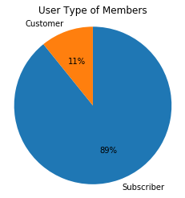

```python
# plotting pie chart
pie_chart(user_type, 'User Type of Members')
```

### Observation

- Subscribers form the majority, accounting for 89% of the users while customers account for 11%.

We gather the value counts for members gender and plot a pie chart

```python
# getting value counts of member_gender
m_gender = bike_data['member_gender'].value_counts()
m_gender
```

```
Male      130340
Female     40765
Other       3644
Name: member_gender, dtype: int64
```

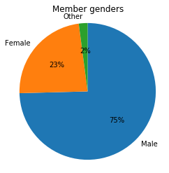

```python
# plotting pie chart
pie_chart(m_gender, 'Member genders')
```

### Q 3: What are the gender dristributions for customers (non-members)

- We first create a variable "customer" which stores user_types for the customers only filtered from the dataframe.
- We then gather value counts for the customer user_types and plot a pie chart

```python
# filtering dataframe to gather user_types for customers only
customer = bike_data[bike_data['user_type'] == 'Customer']

#getting value counts for customers gender
cust_gender = customer['member_gender'].value_counts()

cust_gender
```

```
Male      11483
Female     4622
Other       448
Name: member_gender, dtype: int64
```

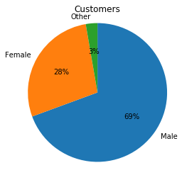

```python
# plotting pie chart
pie_chart(cust_gender, 'Customers')
```

### Observation

- Majority of the non-members are male, accounting for 69% of the customers.
- 28% of these are female while 3% identify as other.

### Q 4: How is age distributed across members

**Note**: We will be plotting histograms in this project, let's define a function to use across the project to avoid code repetition.

```python
# Defining function for histograms

def hist_plot(d_set, x_ax, binz, x_lab, y_lab, ttl):

    plt.hist(data = d_set, x = x_ax, bins = binz)
    plt.xlabel(x_lab)
    plt.ylabel(y_lab)
    plt.title(ttl);
```

> Let's plot two histograms (using `matplotlib` and `seaborn`) side by side to see the **age** distribution representation.

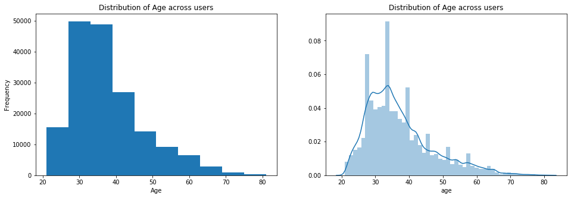

```python
# resizing the chart to have two plots side-by-side
plt.figure(figsize = [16, 5])

# histogram on the left -- using matplotlib
plt.subplot(1, 2, 1)
hist_plot(bike_data, 'age', 10, 'Age',
          'Frequency', 'Distribution of Age across users')

# histogram on the right -- using seaborn
plt.subplot(1, 2, 2)
sb.distplot(bike_data['age']).set(title='Distribution of Age across users');
```

### Observation

**Note**: The bin sizes for the two plot are not equal. The first plot has larger bins while the second has smaller bins.

> Let's equate the bin sizes and see how they compare

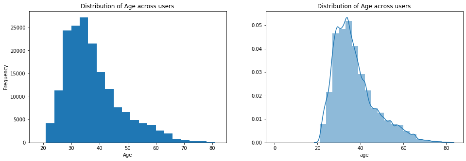

```python
# resizing the chart to have two plots side-by-side
plt.figure(figsize = [16, 5])

# histogram on the left -- using matplotlib
plt.subplot(1, 2, 1)
bins = np.arange(0, bike_data['age'].max()+3, 3)
hist_plot(bike_data, 'age', bins, 'Age',
          'Frequency', 'Distribution of Age across users')
plt.xlim((15, 85))


# histogram on the right -- using seaborn
plt.subplot(1, 2, 2)
bin_edges = np.arange(0, bike_data['age'].max()+3, 3)
sb.distplot(bike_data['age'], bins = bin_edges,
            hist_kws = {'alpha' : 0.5}).set(title='Distribution of Age across users');
```

### Observation

- Both distributions are unimodal
- Both are skewed to the right
- It appears that most members are aged between 25 and 45 years.

### Q 5: How is duration distributed across trips

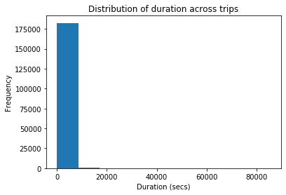

```python
hist_plot(bike_data,'duration_sec',10,'Duration (secs)',
          'Frequency','Distribution of duration across trips')
```

### Observation

- There is nothing much to gather from this visualization.

Let's increase bin sizes to 100 and then limit the x- axis to 5000 to get a clear picture of the data.

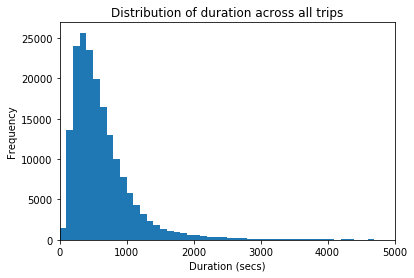

```python
# increasing bin size to 100 and reducing x-axis limit to 5000

bins = np.arange(0, bike_data['duration_sec'].max()+100, 100)
hist_plot(bike_data,'duration_sec', bins,'Duration (secs)','Frequency','Distribution of duration across all trips')
plt.xlim((0, 5000));
```

### Observation

- The distribution is unimodal and skewed to the right.

### Discuss the distribution(s) of your variable(s) of interest. Were there any unusual points? Did you need to perform any transformations?

> The distributions showed that majority of users (89%) of the system are subscribed while only 11% of the users are not. For both subscribers and non-subscribers, males account for the highest percentages followed by females and lastly others. Those identifying as others could be members of the "LGBTQ" community. We could conclude that men are fond of bike riding than the other genders.

> The distributions on **Age** showed that the majority of riders are between ages 25 and 45, while the vast minority is the elderly. This means that youth and middle aged people are more into bike riding than the elderly.

> Distributions on the duration showed a majority of the users averaging about 726 seconds (10 to 15 minutes) rides. There are lesser people riding for longer durations.

**Transformations:** To show age distributions, I had to create a column (age) from the differnce of current year of working this project **(2022)** and each members' year of birth.

### Of the features you investigated, were there any unusual distributions? Did you perform any operations on the data to tidy, adjust, or change the form of the data? If so, why did you do this?

> For age distribution, I equated the bin sizes for uniformity since i was using both matplotlib and seaborn in plotting.

> For duration, the initial distribution was just one bar with an almost-unclear outlier , I changed the bin size to 100 so as to get a detailed distribution of the data. I also reduced the axis limits to 5000 for clarity of peaks.

## Bivariate Exploration

> Now let's investigate relationships between pairs of variables in out dataset.

### Q 6: How is age distributed across gender for members

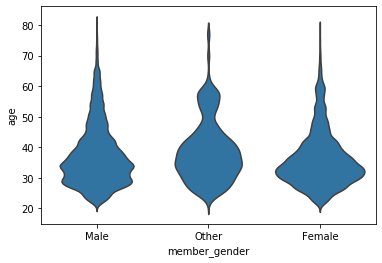

```python
sb.violinplot(data=bike_data, x='member_gender', y='age', inner=None, color=sb.color_palette()[0]);
```

### Observation

- There is a slight bimodality in the **"other"** genders
- The **"female"** gender seems to have a broader distribution between ages 30 to 35.
- The average age has peaks at almost the same point in aech of the three categories.

Let's plot a box-plot and see if it reveals some more insights.

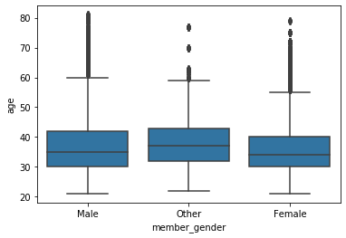

```python
# plotting box plot
base_color = sb.color_palette()[0]

sb.boxplot(data=bike_data, x='member_gender', y='age', color=base_color);
```

### Observation

- The **"other"** gender category has the highest median ages, followed by **"male"** and **"female"** has the lowest age median.
- There are outliers in the **"other"** and **"female"** gender categories

### Q7: How age distrubuted across user types

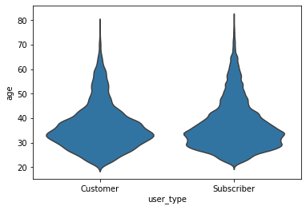

```python
# plotting violin-plot
sb.violinplot(data=bike_data, x='user_type', y='age', inner=None, color=sb.color_palette()[0]);
```

### Observation

- Both customer and subscriber types average the same age
- However, customer has a sharper peak distribution than subscriber.

Let's plot a box plot for their average statistics.

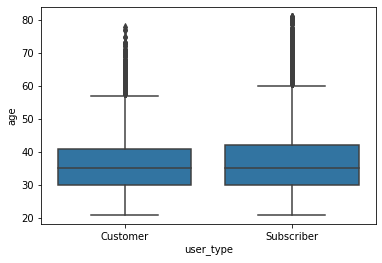

```python
# plotting box plot
base_color = sb.color_palette()[0]

sb.boxplot(data=bike_data, x='user_type', y='age', color=base_color);
```

### Observation

- There are outliers in the customers category.
- There is a slightly bigger number of middle-aged subcribers than customers. However, the median age seems to be the same.

### Q 8: How is duration distributed across user types

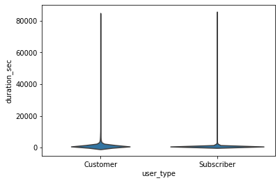

```python
# plotting violin plot
sb.violinplot(data=bike_data, x='user_type', y='duration_sec', inner=None, color=sb.color_palette()[0]);
```

### Observation

- The durations for both user types seem to be consentrated at zero (0).
- Both distributions have very high outliers.

Let's expand the y-axis limit to get a clear understanding.

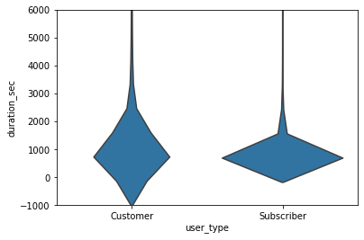

```python
# expanding y-axis for closer look
sb.violinplot(data=bike_data, x='user_type', y='duration_sec', inner=None, color=sb.color_palette()[0]);
plt.ylim((-1000,6000));
```

### Observation

- More customers than subscribers seem to be taking longer ride durations.
- The subsrcibers distribution is broader at the mean (726 seconds -- 12 minutes) .

> Let's use a box plot for summary insights.

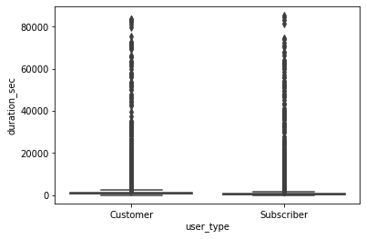

```python
# plotting user_type vs duration_sec
sb.boxplot(data=bike_data, x='user_type', y='duration_sec');
```

### Observation

- Both categories have huge outliers.
- There is not much to interpret from the above since a lot of the data seems to be consentrated somewhere close to 0 seconds for both customer and subscriber category.

Let's limit the y-axis to get a clear visual of the summary statistics of this visualization.

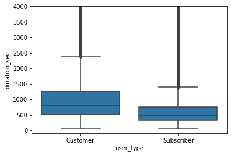

```python
# summary statistics for user_type vs duration_sec
base_color = sb.color_palette()[0]
sb.boxplot(data=bike_data, x='user_type', y='duration_sec', color = base_color)

#limiting the y-axis limits
plt.ylim((-100,4000));
```

### Observation

- The **customer** category has a higher mean than the **subscriber** category.
- The **customer** category has the largest average trip duration. This confirms that on average, customers trips took longer than those of subscribers.

### Q9: How is duration distributed across gender

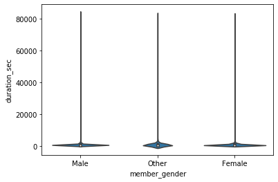

```python
# violin plot -- member_gender vs duration_sec
sb.violinplot(data=bike_data, x='member_gender', y='duration_sec', color=sb.color_palette()[0]);
```

### Observation

- There are outliers in each gender category which are very high.
- The distributions for each gender are highly consentrated close to zer (0). This is not very informative.

> Let's expand the y-axis limit to get a closer look at the consentrated distribution points.

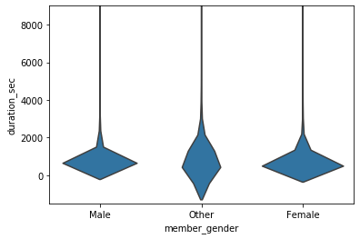

```python
# expanding y-axis limits -- member_gender vs duration_sec
sb.violinplot(data=bike_data, x='member_gender', y='duration_sec', inner=None, color=sb.color_palette()[0])
plt.ylim((-1500, 9000));
```

### Observation

- All three gender distributions have their peak at almost the same point.
- The male and female distributions however have wider peaks than the other gender distribution.

> Let's look at insights from a box plot of these variables

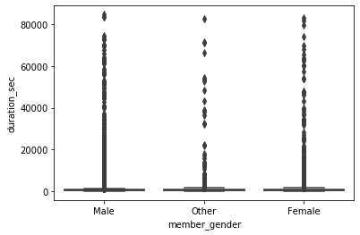

```python
# summary statistics -- member_gender vs duration_sec
sb.boxplot(data=bike_data, x='member_gender', y='duration_sec');
```

### Observation

- The outliers are clearer with the "other" gender representation having lesser and inconsistent outliers.
- Distributions are highly consentrated at one point.

> Let's limit the y-axis to get a closer look at the summary statistics

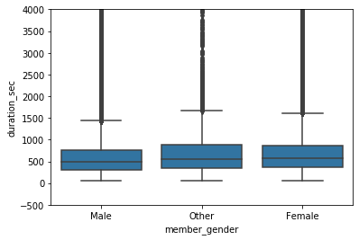

```python
base_color = sb.color_palette()[0]

# expanding y- limits for closer look
sb.boxplot(data=bike_data, x='member_gender', y='duration_sec', color = base_color)
plt.ylim((-500,4000));
```

### Observation

- All three gender categories seem to have the same average duration.
- The other gender distribution is slightly bigger than both male and female category.

### Q 10: How does age relate to riding duration

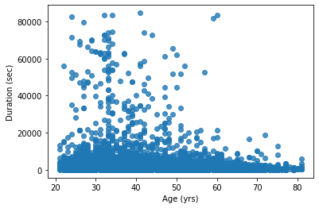

```python
# scatterplot -- age vs _duration_sec
sb.regplot(data = bike_data, x = 'age', y = 'duration_sec')
plt.xlabel('Age (yrs)')
plt.ylabel('Duration (sec)');
```

### Observation

- Data points are highly consentrated between zero (0) and 1000 seconds.
- There are outliers between ages 20 an 60.

Let's add some transparency and jitter for a better look.

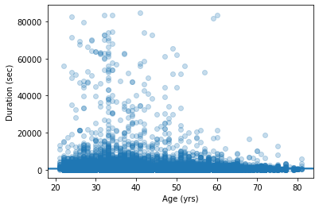

```python
sb.regplot(data = bike_data, x = 'age', y = 'duration_sec', truncate=False, y_jitter=0.7, scatter_kws={'alpha':5/20});
plt.xlabel('Age (yrs)')
plt.ylabel('Duration (sec)')
```

### Observation

- Based on the outliers, it seems more young and middle-aged people ride for longer durations than the elderly.

Now let's reduce the y-axis limits to have a closer look at the consentrated points.

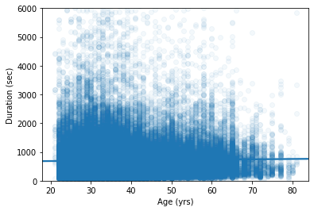

```python
sb.regplot(data = bike_data, x = 'age', y = 'duration_sec', truncate=False, y_jitter=0.7, scatter_kws={'alpha':1/20});
plt.xlabel('Age (yrs)')
plt.ylabel('Duration (sec)')
plt.ylim((0,6000));
```

### Q11: What are the 10 most preferred stations to start from

We plot this from the ten (10) start stations with the highest value counts. Let's first define a function to plot bar charts.

```python
def bar_plot2(d_set, x_ax, y_ax, x_lab, y_lab, ttl, clor):

    sb.barplot(data = d_set, x = x_ax, y = y_ax, color = clor)
    plt.xlabel(x_lab)
    plt.ylabel(y_lab)
    plt.title(ttl);
```

Let's look at the stations value counts (number of times users have started from that station

```python
bike_data['start_station_name'].value_counts()
```

```
Market St at 10th St                                         3903
San Francisco Caltrain Station 2  (Townsend St at 4th St)    3529
Berry St at 4th St                                           3050
Montgomery St BART Station (Market St at 2nd St)             2893
Powell St BART Station (Market St at 4th St)                 2760
                                                             ...
Willow St at Vine St                                            9
Parker Ave at McAllister St                                     7
Palm St at Willow St                                            4
21st Ave at International Blvd                                  4
16th St Depot                                                   2
Name: start_station_name, Length: 329, dtype: int64
```

To answer this question, we:

- gather the stations with the top 10 value counts
- create a dataframe from the gathered data
- plot

```python
# gathering top ten stations
start_counts = bike_data['start_station_name'].value_counts()
top_ten = start_counts[:10]

# creating dataframe and reseting index
top_ten = pd.DataFrame(top_ten.reset_index()).rename(columns={'start_station_name':'start_counts','index':'start_station_name'})
top_ten
```

|  | start_station_name | start_counts |
| --- | --- | --- |
| 0 | Market St at 10th St | 3903 |
| 1 | San Francisco Caltrain Station 2 (Townsend St... | 3529 |
| 2 | Berry St at 4th St | 3050 |
| 3 | Montgomery St BART Station (Market St at 2nd St) | 2893 |
| 4 | Powell St BART Station (Market St at 4th St) | 2760 |
| 5 | San Francisco Ferry Building (Harry Bridges Pl... | 2708 |
| 6 | San Francisco Caltrain (Townsend St at 4th St) | 2695 |
| 7 | Powell St BART Station (Market St at 5th St) | 2326 |
| 8 | Howard St at Beale St | 2292 |
| 9 | Steuart St at Market St | 2273 |

Now that we have a dataframe of the top ten stations from which people started riding, let's plot.

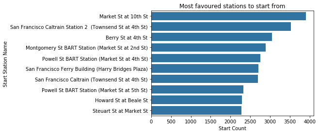

```python
# barplot -- start station vs start count
base_color = sb.color_palette()[0]
bar_plot2(top_ten, 'start_counts', 'start_station_name', 'Start Count',
          'Start Station Name', 'Most favoured stations to start from', base_color)
```

### Observation

- Above are the 10 most preffered statios to start from.
- The most popular station to start from is the **Market St at 10th Street** station.

Now let's look at the 10 most preffered stations to finish riding at.

### Q 12: What are the 10 most preferred stations to finish riding at

```python
# gathering top ten stations
end_counts = bike_data['end_station_name'].value_counts()
ten_end = end_counts[:10]

# creating dataframe and reseting index
ten_end = pd.DataFrame(ten_end.reset_index()).rename(columns={'end_station_name':'end_counts','index':'end_station_name'})
ten_end
```

|  | end_station_name | end_counts |
| --- | --- | --- |
| 0 | San Francisco Caltrain Station 2 (Townsend St... | 4854 |
| 1 | Market St at 10th St | 3966 |
| 2 | Montgomery St BART Station (Market St at 2nd St) | 3646 |
| 3 | San Francisco Ferry Building (Harry Bridges Pl... | 3368 |
| 4 | Powell St BART Station (Market St at 4th St) | 2996 |
| 5 | San Francisco Caltrain (Townsend St at 4th St) | 2937 |
| 6 | Berry St at 4th St | 2860 |
| 7 | The Embarcadero at Sansome St | 2512 |
| 8 | Powell St BART Station (Market St at 5th St) | 2352 |
| 9 | Steuart St at Market St | 2338 |

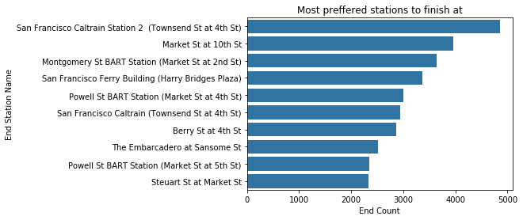

```python
base_color = sb.color_palette()[0]
bar_plot2(ten_end, 'end_counts', 'end_station_name', 'End Count',
          'End Station Name', 'Most preffered stations to finish at', base_color)
```

### Observation

- These are the 10 most preffered stations to finish riding at.
- The station with the highets number of end counts is **San Fransisco Caltrain Station 2**.

.

**Note**: It is interesting that 9 out of the 10 stations with the highest start count (exception of **Howard St at Beale Station**) are also among the top ten stations with the highest end count (exception of **The Embarcadero at Sansome Station**)

### Talk about some of the relationships you observed in this part of the investigation. How did the feature(s) of interest vary with other features in the dataset?

> Based on the analysis, it is evident that biking is male dominated as we have a large number of male riders both in customer and subscriber categories.

> Most riders are either youth or middle-aged in both user categories and also they avergae higher riding durations as expected. It is however interesting that there are elderly people who can average close to 10 minutes of riding.

### Did you observe any interesting relationships between the other features (not the main feature(s) of interest)?

> When looking at riding duration across user types (customer and subcriber), I noticed that customers(non-members) average higher durations than subscribers. This is counter-intuitive as one would expect subscribers (who are definitely bike lovers) to average higher durations than regular customers.

However, this could either be because, since most customers are not (**presumably**) regular riders, every time they decide to ride, they do it for longer to quench their longing and excitement, **or**, averages for subscribers are lower because of their consideraley large number than customers, which affects computations.

> Another feature of interest was how top 9 most preffered start stations were also among the most preffered stations to finish at.

## Multivariate Exploration

> Finally, lets look at relationships between three or more variables in our dataset.

### Q 13: How is riding duration distributed among gender for each user type

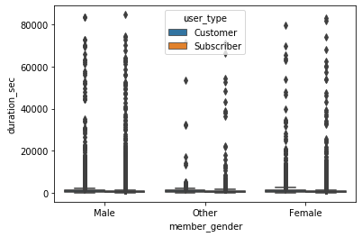

```python
# boxplot -- member_gender vs duration_sec vs user_type
sb.boxplot(data = bike_data, x='member_gender',y='duration_sec', hue='user_type')
```

### Observation

- There are huge outliers in riding duration of all gender categories

Since we can't make of anything from the box plots, lets limit the y-axis to get a closer look at the summaries.

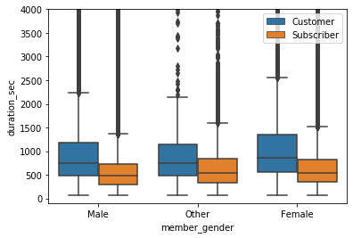

```python
# expanding y-axis limits
sb.boxplot(data = bike_data, x='member_gender',y='duration_sec', hue='user_type')
plt.ylim((-100,4000))
plt.legend(loc=1)
```

### Observation

- For all three gender categories, customers seem to average more durations than subscribers.

Let's use a pointplot for a deeper look

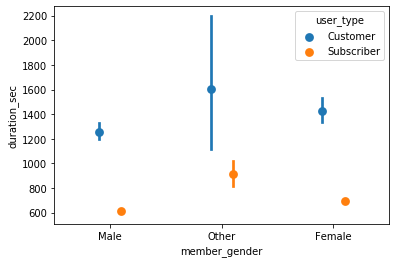

```python
# plotting with pointplot
sb.pointplot(data = bike_data, x = 'member_gender', y = 'duration_sec', hue = 'user_type',
                  dodge = 0.2, linestyles = "");
```

### Observation

- As noticed earlier, customers average higher durations than subscribers in all three gender categories.
- It is however interesting that the female gender records higher averages than male. This could be because the total number of males is way higher than that of females and therefore records lower averages.

### Q 14: How is Age distributed among gender for each user type

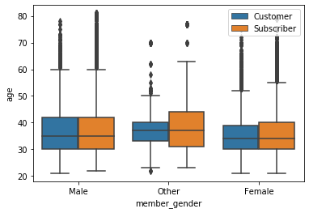

```python
# boxplot -- member_gender vs age vs user_type
sb.boxplot(data = bike_data, x='member_gender',y='age', hue='user_type')
plt.legend(loc=1)
```

### Observation

- Based on the outliers, there are not many elderly people who identify their gender as **other** in both customers and subscribers.

Let'suse a pointplot for a closer look

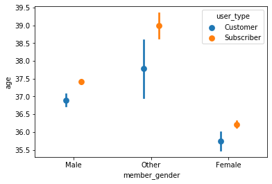

```python
# pointplot -- member_gender vs age vs user_type
sb.pointplot(data = bike_data, x = 'member_gender', y = 'age', hue = 'user_type',
                  dodge = 0.2, linestyles = "")
```

### Observation

- Generally, subscribers record slightly higher average ages across the gender categories.
- Rider identifyng as **other** have the highest average age followed by **male** and lastly **women**
- It's important to note that the average ages across the two demographics are for middle-aged people

### Q 15: Compare start and end counts for each top ten stations

.

Here, we will:

- merge the two station dataframes we created during bivariate analysis (`top_ten` and `ten_end`) into one (`top_station`).
- Plot a clustered bar chart to see how the start and end counts compare in each of the nine stations.

**Note**: The two unmatching stations in the datasets are *Howard St at Beale St* (start station) and *The Embarcadero at Sansome St* (end station).

**Define**

To merge these two dataframes, we will:

- Drop each unmatching station's row from the respective dataframe
- Sort the order of the station names alphabetically in both dataframes for easy merging
- Merge the two dataframes
- Rename start_station_name to `station_name` and drop the end_station_name row.

. Let's have a quick look at the two datasets

```python
top_ten
```

|  | start_station_name | start_counts |
| --- | --- | --- |
| 0 | Market St at 10th St | 3903 |
| 1 | San Francisco Caltrain Station 2 (Townsend St... | 3529 |
| 2 | Berry St at 4th St | 3050 |
| 3 | Montgomery St BART Station (Market St at 2nd St) | 2893 |
| 4 | Powell St BART Station (Market St at 4th St) | 2760 |
| 5 | San Francisco Ferry Building (Harry Bridges Pl... | 2708 |
| 6 | San Francisco Caltrain (Townsend St at 4th St) | 2695 |
| 7 | Powell St BART Station (Market St at 5th St) | 2326 |
| 8 | Howard St at Beale St | 2292 |
| 9 | Steuart St at Market St | 2273 |

```python
ten_end
```

|  | end_station_name | end_counts |
| --- | --- | --- |
| 0 | San Francisco Caltrain Station 2 (Townsend St... | 4854 |
| 1 | Market St at 10th St | 3966 |
| 2 | Montgomery St BART Station (Market St at 2nd St) | 3646 |
| 3 | San Francisco Ferry Building (Harry Bridges Pl... | 3368 |
| 4 | Powell St BART Station (Market St at 4th St) | 2996 |
| 5 | San Francisco Caltrain (Townsend St at 4th St) | 2937 |
| 6 | Berry St at 4th St | 2860 |
| 7 | The Embarcadero at Sansome St | 2512 |
| 8 | Powell St BART Station (Market St at 5th St) | 2352 |
| 9 | Steuart St at Market St | 2338 |

Now we start merging

```python
# dropping Howard St at Beale St row and resetting index
start_stations = top_ten.drop([top_ten.index[8]]).reset_index().drop('index', axis=1)

# dropping The Embarcadero at Sansome St row
end_stations = ten_end.drop([ten_end.index[7]]).reset_index().drop('index', axis=1)
```

```python
# sorting the station names alphabetically for easy merging
starting = start_stations.sort_values(by = ['start_station_name']).reset_index().drop('index', axis=1)
ending = end_stations.sort_values(by = ['end_station_name']).reset_index().drop('index', axis=1)
```

```python
starting
```

|  | start_station_name | start_counts |
| --- | --- | --- |
| 0 | Berry St at 4th St | 3050 |
| 1 | Market St at 10th St | 3903 |
| 2 | Montgomery St BART Station (Market St at 2nd St) | 2893 |
| 3 | Powell St BART Station (Market St at 4th St) | 2760 |
| 4 | Powell St BART Station (Market St at 5th St) | 2326 |
| 5 | San Francisco Caltrain (Townsend St at 4th St) | 2695 |
| 6 | San Francisco Caltrain Station 2 (Townsend St... | 3529 |
| 7 | San Francisco Ferry Building (Harry Bridges Pl... | 2708 |
| 8 | Steuart St at Market St | 2273 |

```python
ending
```

|  | end_station_name | end_counts |
| --- | --- | --- |
| 0 | Berry St at 4th St | 2860 |
| 1 | Market St at 10th St | 3966 |
| 2 | Montgomery St BART Station (Market St at 2nd St) | 3646 |
| 3 | Powell St BART Station (Market St at 4th St) | 2996 |
| 4 | Powell St BART Station (Market St at 5th St) | 2352 |
| 5 | San Francisco Caltrain (Townsend St at 4th St) | 2937 |
| 6 | San Francisco Caltrain Station 2 (Townsend St... | 4854 |
| 7 | San Francisco Ferry Building (Harry Bridges Pl... | 3368 |
| 8 | Steuart St at Market St | 2338 |

We have successfuly dropped the onmatching rows in each dataset

```python
# merging the two tables
top_stations = pd.merge(starting, ending, left_index=True, right_index=True)
top_stations
```

|  | start_station_name | start_counts | end_station_name | end_counts |
| --- | --- | --- | --- | --- |
| 0 | Berry St at 4th St | 3050 | Berry St at 4th St | 2860 |
| 1 | Market St at 10th St | 3903 | Market St at 10th St | 3966 |
| 2 | Montgomery St BART Station (Market St at 2nd St) | 2893 | Montgomery St BART Station (Market St at 2nd St) | 3646 |
| 3 | Powell St BART Station (Market St at 4th St) | 2760 | Powell St BART Station (Market St at 4th St) | 2996 |
| 4 | Powell St BART Station (Market St at 5th St) | 2326 | Powell St BART Station (Market St at 5th St) | 2352 |
| 5 | San Francisco Caltrain (Townsend St at 4th St) | 2695 | San Francisco Caltrain (Townsend St at 4th St) | 2937 |
| 6 | San Francisco Caltrain Station 2 (Townsend St... | 3529 | San Francisco Caltrain Station 2 (Townsend St... | 4854 |
| 7 | San Francisco Ferry Building (Harry Bridges Pl... | 2708 | San Francisco Ferry Building (Harry Bridges Pl... | 3368 |
| 8 | Steuart St at Market St | 2273 | Steuart St at Market St | 2338 |

```python
# renaming start_station_name to station_name and dropping the end_station_name row.
top_stations = top_stations.rename(columns={'start_station_name':'station_name'}).drop('end_station_name', axis=1)
top_stations
```

|  | station_name | start_counts | end_counts |
| --- | --- | --- | --- |
| 0 | Berry St at 4th St | 3050 | 2860 |
| 1 | Market St at 10th St | 3903 | 3966 |
| 2 | Montgomery St BART Station (Market St at 2nd St) | 2893 | 3646 |
| 3 | Powell St BART Station (Market St at 4th St) | 2760 | 2996 |
| 4 | Powell St BART Station (Market St at 5th St) | 2326 | 2352 |
| 5 | San Francisco Caltrain (Townsend St at 4th St) | 2695 | 2937 |
| 6 | San Francisco Caltrain Station 2 (Townsend St... | 3529 | 4854 |
| 7 | San Francisco Ferry Building (Harry Bridges Pl... | 2708 | 3368 |
| 8 | Steuart St at Market St | 2273 | 2338 |

Now our dataset is clean and ready for plotting. Let's sort it by the end_counts to get a seamless final plot.

```python
# sorting dataframe by end_counts
top_stations.sort_values(by=['end_counts'], inplace=True)
top_stations
```

|  | station_name | start_counts | end_counts |
| --- | --- | --- | --- |
| 8 | Steuart St at Market St | 2273 | 2338 |
| 4 | Powell St BART Station (Market St at 5th St) | 2326 | 2352 |
| 0 | Berry St at 4th St | 3050 | 2860 |
| 5 | San Francisco Caltrain (Townsend St at 4th St) | 2695 | 2937 |
| 3 | Powell St BART Station (Market St at 4th St) | 2760 | 2996 |
| 7 | San Francisco Ferry Building (Harry Bridges Pl... | 2708 | 3368 |
| 2 | Montgomery St BART Station (Market St at 2nd St) | 2893 | 3646 |
| 1 | Market St at 10th St | 3903 | 3966 |
| 6 | San Francisco Caltrain Station 2 (Townsend St... | 3529 | 4854 |

[figure not shown]

```python
# plotting horizontal clustered bar chart for the table **top_stations**

top_stations.plot.barh(x='station_name', y=['start_counts','end_counts'])
plt.xlabel('Number of departures, arrivals')
plt.ylabel('Station Name')
plt.title('Stations with highest number of starts and finishes');
```

### Observation

- All stations except **Berry St at 4th St** recorded higher end counts than start counts.
- It is clear that a higher start count does not guarantee an equally higher end count.
- It also seems that the order of preferance for stations to start riding from is **almost** the same as that of stations to end at.

### Talk about some of the relationships you observed in this part of the investigation. Were there features that strengthened each other in terms of looking at your feature(s) of interest?

> Just as observed in bivariate analysis, there are still higher riding duration averages for customers than subscribers in each of the three gender categories. It is however interesting that the female gender records higher averages than male in all user categories. This may be because larger data samples generally record lower averages.

> The analysis on age across genders among the two user types showed that most riders were middle-aged. Most of these made up of subscribers. Riders in the LGBTQ community had higher averages than the other gender categoeries.

### Were there any interesting or surprising interactions between features?

> The most interesting interaction was where we recorded higher duration averages for cutomers than subscribers.

## Conclusion

**IMPORTANT:** The concluions reached from answering the questions asked are based on analysis done for data of bike users *born between 1941 (currently aged 80) and the present year (2022) and not based on the entire dataset.

We can conclude that, Subscribers form the majority of users, accounting for 89% of all bike users while Customers make up for the remaining 11% of bike users. It is also evident that biking is male dominated since we have the largest number of users being Male in both Customer and Subscriber categories.

Most riders are either youth or middle-aged (ages of 25-45 years) in both user categories. Generally, Subscribers record slightly higher average ages than Customers across the three gender categories. It's important to note that the average ages across the two user types are for middle-aged people.